# HW05: Factor and Figure Management

Carleena Ortega

17/10/2019

```r
suppressPackageStartupMessages(library(gapminder))
suppressPackageStartupMessages(library(forcats))
suppressPackageStartupMessages(library(ggplot2))
suppressPackageStartupMessages(library(tidyverse))
suppressPackageStartupMessages(library(dplyr))
suppressPackageStartupMessages(library(scales))
suppressPackageStartupMessages(library(here))
```

# Exercise 1: Explain the value of the here::here package

In your own words, summarize the value of the here::here package in 250 words or fewer.

The here::here package is similar to the base R function file.path() since it allows the user to write files safely along paths. One of the advantages of the here::here package over is that it can be recognized by different platforms(Windows, Apple, etc.). Another advantage of the here::here package is the ability to save files along a pathway without explicitly stating the pathway, which saves time and is less frustrating. It can also load files and save them in a different pathway (if desired) without the hassle of figuring out and stating the entire pathways. It is also allows the reproducibility of files as it allows other people to run your code. Lastly, it allows opening .R files when using a new session.

# Exercise 2: Factor management

We choose the `gapminder` dataset and select `continent` as the factor to explore. The code below determines whether gapminder’s continent is a factor or not; how many levels it has and what these levels are. In addition, we also use the str() command to show a summary of the dataset, including how many observations (rows) we have.

```r
class(gapminder$continent)
```

```
## [1] "factor"
```

```r
nlevels(gapminder$continent)
```

```
## [1] 5
```

```r
levels(gapminder$continent)
```

```
## [1] "Africa"   "Americas" "Asia"     "Europe"   "Oceania"
```

```r
str(gapminder)
```

```
## Classes 'tbl_df', 'tbl' and 'data.frame':    1704 obs. of  6 variables:
##  $ country  : Factor w/ 142 levels "Afghanistan",..: 1 1 1 1 1 1 1 1 1 1 ...
##  $ continent: Factor w/ 5 levels "Africa","Americas",..: 3 3 3 3 3 3 3 3 3 3 ...
##  $ year     : int  1952 1957 1962 1967 1972 1977 1982 1987 1992 1997 ...
##  $ lifeExp  : num  28.8 30.3 32 34 36.1 ...
##  $ pop      : int  8425333 9240934 10267083 11537966 13079460 14880372 12881816 13867957 16317921 22227415 ...
##  $ gdpPercap: num  779 821 853 836 740 ...
```

We now know that `continent` is a factor with 5 levels named Africa, Americas, Asia, Europe, and Oceania. We also have 1704 rows or observations as shown by the str() function.

Our next step is to filter and drop levels. We filter out Oceania and then drop the unused factor levels in continent.

```r
drop_Ocn<-gapminder %>%
  filter(continent !="Oceania") %>%
  droplevels()

drop_Ocn$continent %>%
  nlevels()
```

```
## [1] 4
```

```r
drop_Ocn$continent %>%
  levels()
```

```
## [1] "Africa"   "Americas" "Asia"     "Europe"
```

```r
str(drop_Ocn)
```

```
## Classes 'tbl_df', 'tbl' and 'data.frame':    1680 obs. of  6 variables:
##  $ country  : Factor w/ 140 levels "Afghanistan",..: 1 1 1 1 1 1 1 1 1 1 ...
##  $ continent: Factor w/ 4 levels "Africa","Americas",..: 3 3 3 3 3 3 3 3 3 3 ...
##  $ year     : int  1952 1957 1962 1967 1972 1977 1982 1987 1992 1997 ...
##  $ lifeExp  : num  28.8 30.3 32 34 36.1 ...
##  $ pop      : int  8425333 9240934 10267083 11537966 13079460 14880372 12881816 13867957 16317921 22227415 ...
##  $ gdpPercap: num  779 821 853 836 740 ...
```

We have successfully filtered out the data from Oceania as we now have only 4 levels in continent named Africa, Americas, Asia, and Europe. The str() function also shows that we have 1680 observations, which is less than the original dataset (1704 observations).

Our next goal is to explore the effects of re-leveling a factor with the modified gapminder data set. For this, we will use the summarized max gross domestic product (GDP) per capita of each continent.

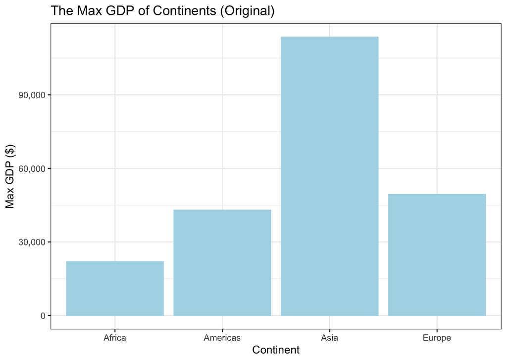

```r
drop_Ocn %>%
  select(continent,gdpPercap) %>%
  group_by(continent) %>%
  summarize(maxGDP=max(gdpPercap)) %>%
  arrange(maxGDP) %>%
  ggplot(aes(x= continent, y =maxGDP))+
  geom_bar(stat='identity', colour="light blue", fill="light blue")+
  labs(x="Continent",y="Max GDP ($)",title="The Max GDP of Continents (Original)")+
  scale_y_continuous(labels=comma)+
  theme_bw()
```

The arrange() command applies just to the tibble and did not affect the plot so the continents are arranged in the default alphabetic order. We can modify the above graph and re-order the continents using the forcats package as shown below.

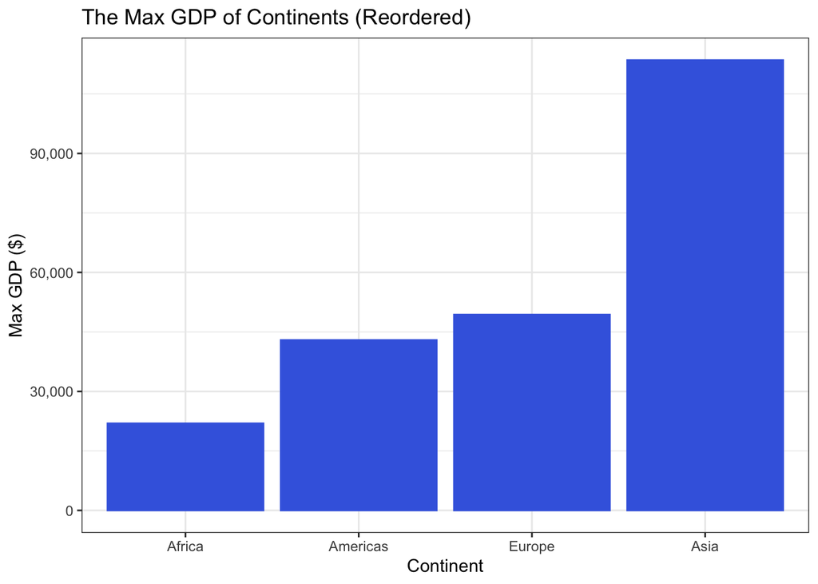

```r
drop_Ocn %>%
  select(continent,gdpPercap) %>%
  group_by(continent) %>%
  summarize(maxGDP=max(gdpPercap)) %>%
  ggplot(aes(x= fct_reorder(continent,maxGDP), y =maxGDP)) +
  geom_bar(stat = 'identity',colour="royal blue",fill="royal blue")+
  labs(x="Continent",y="Max GDP ($)",title="The Max GDP of Continents (Reordered)")+
  scale_y_continuous(labels=comma)+
  theme_bw()
```

This is a more intuitive way of presenting the max GDP of each continent compared to the first plot. It shows the plots in an ascending order that makes it easy to see that Africa has the lowest GDP and Asia has the highest GDP. It also makes it easier to compare between continents.